# PF3.2a: To Make & Work with Trees - from Phylomatic to OTL, ROTL and TreeBase

This is a follow-up and complement to the R Notebook used during our digital lab session on 3/8.

By the way, that previous file (look for the file that starts PF3.1) can be downloaded and worked through as a review, and it has updates and clarifications.

Working through this notebook and its exercises will add one more point to the 3 earned from PF3.1.

You may find this helpful if you are struggling with creating phylogenies.

## Review of APE and BRRANCHING

Our digital lab sessions and a previous R Notebook introduced the R packages APE and BRRANCHING, A strength of BRRANCHING is that it can access the on-line resource Phylomatic, a reference phylogeny for angiosperms.

```r
library('ape')
library('brranching')
```

Lists of angiosperm taxa (species, genera, families) can be used to download a Phylomatic phylogeny into R, where it can be visualized. Below is a previous example, using the level of genus.

Such a file can be exported from R software in Newick of Nexus format, and that file can be imported into other programs such as FigTree.

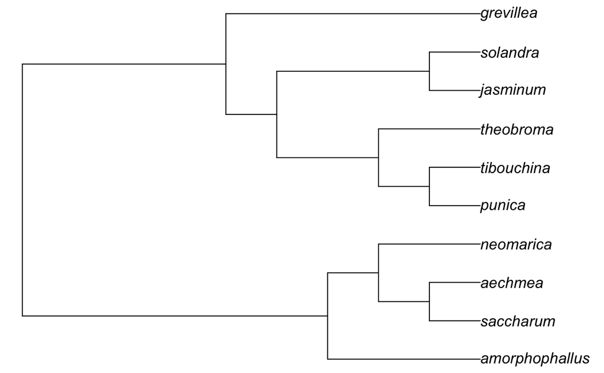

```r
taxa<-c("Punica", "Theobroma", "Neomarica", "Aechmea", "Solandra", "Grevillea", "Jasminum", "Tibouchina", "Amorphophallus", "Saccharum")
tree_phylomatic <- phylomatic(taxa = taxa, get = 'POST')
plot(tree_phylomatic, no.margin = TRUE)
```

```r
taxa
```

```
 [1] "Punica"         "Theobroma"      "Neomarica"      "Aechmea"
 [5] "Solandra"       "Grevillea"      "Jasminum"       "Tibouchina"
 [9] "Amorphophallus" "Saccharum"
```

```r
nexus_fn = "tree_phylomatic"
write.tree(tree_phylomatic, file=nexus_fn)
```

## Accessing Phylomatic through a browser

In addition to accessing Phylomatic through the package branching, it’s also possible to access it directly in a browser: http://phylodiversity.net/phylomatic/ and you should review and further familiarize yourself with Phylomatic. (As appropriate, add some annotations to this notebook to summarize what you’ve learned and done.)

In Phylomatic’s browser interface, you need to select a stored tree from the pull-down menu, which could be the Phylomatic tree (R20120829) or you could try using slik2015 and zanne2014. Personally, I was impressed by the zanne2014. Check it out. Can you discern the strengths of this reference phylogeny? You might want to read a paper about how its been updated, by Qian & Jin 2016 J Pl Ecol 9(2):233-239 (http://dx.doi.org/10.1093/jpe/rtv047)

To enter your list of taxa, the list used above within R requires modification to use directly in Phylomatic’s web-based interface, which requires “slashpath” format and inclusion of families.

lythraceae/Punica malvaceae/Theobroma iridaceae/Neomarica bromeliaceae/Aechmea solanaceae/Solandra proteaceae/Grevillea oleaceae/Jasminum melastomataceae/Tibouchina araceae/Amorphophallus poaceae/Saccharum

Under “outformat” the default output, Newick, is what you want.

## Different stored trees in BRRANCHING – details of the command tree_phylomatic

What if you wanted to access the slik2015 or zanne2014 tree when working in R, it’s fairly straightforward. Simply add an argument to the command above:

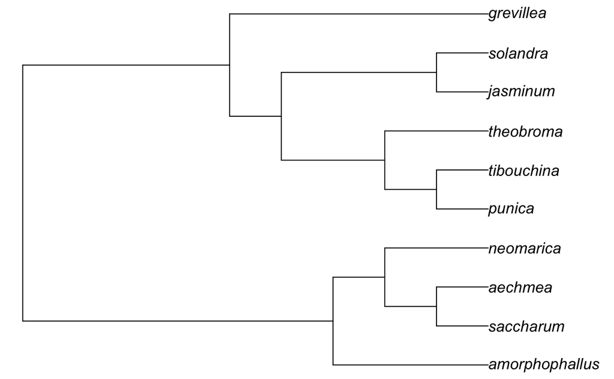

```r
taxa<-c("Punica", "Theobroma", "Neomarica", "Aechmea", "Solandra", "Grevillea", "Jasminum", "Tibouchina", "Amorphophallus", "Saccharum")
tree_R20120829 <- phylomatic(taxa = taxa, get = 'POST')
tree_zanne2014 <- phylomatic(taxa = taxa, storedtree ="zanne2014", get = 'POST')
plot(tree_R20120829, no.margin = TRUE)
```

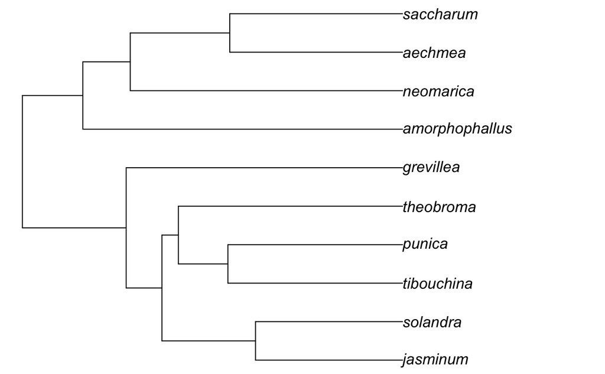

```r
plot(tree_zanne2014, no.margin = TRUE)
```

```r
default_fn = "tree_phylomatic_R20120829"
write.tree(tree_R20120829, file=default_fn)
default_fn = "tree_phylomatic_zanne2014"
write.tree(tree_zanne2014, file=default_fn)
```

How do these two trees compare? Do they show the same relationships among taxa and clades? Is something else different? (Hint: compare lengths of branches within and between trees.)

## Open Tree of Life and the ROTL Package

Another tool to be introduced in this R Notebook is Open Tree of Life, below

https://tree.opentreeoflife.org/opentree/argus/opentree9.1@ott93302

Go and explore this, searching for plant clades such as “Tracheophyta” or “Euphyllophyta”

Open Tree of Life can be used in connection with an R OpenScience package, RTOL.

The first thing to do is to install the package ROTL (uncomment to do so, then re-comment it.) Alwaysremember to re-load the package from your library if you are returning to work at a later and separate session in R Studio

```r
#install.packages("rotl")
library("rotl")
#vignette("how-to-use-rotl", package="rotl")
```

This notebook reproduces material from vignette(“how-to-user-rotl”) and extends it with some plant examples.

## Background: What is ROTL?

rotl is one among many tools within R OpenScience

https://ropensci.org/

rotl provides an interface to the Open Tree of Life (OTL) API and allows users to query the API, retrieve parts of the Tree of Life and integrate these parts with other R packages.

The OTL API provides services to access to the Tree of Life, which uses a system for naming and identifying taxa called OTT (for Open Tree Taxonomy). If you have names of species (or general, or families) then you can query for the OTT directly using features of ROTL, as below.

- the Tree of Life a.k.a. TOL (the synthetic tree): a single draft tree that is a combination of the OTL taxonomy and the source trees (studies) . . . these features begin with the prefix tol_
- the Taxonomic name resolution services a.k.a. TNRS: the methods for resolving taxonomic names to the internal identifiers used by the TOL and the GOL (the ott ids) . . . these features begin with the prefix tnrs_
- the Taxonomy a.k.a. OTT (for Open Tree Taxonomy): which represents the synthesis of the different taxonomies used as a backbone of the TOL when no studies are available . . . these features begin with the prefix taxonomy_
- the Studies containing the source trees used to build the TOL, and extracted from the scientific literature . . . these features begin with the prefix studies_

rotl also provides a few other functions and methods that can be used to extract relevant information from the objects returned by these functions. You can activate a vignette that will appear in the lower right window of R studio if you use the command

```r
vignette("how-to-use-rotl", package="rotl")
```

## Demonstration of a basic workflow

The most common use for rotl is to start from a list of species and get the relevant parts of the tree for these species. This is a two step process:

1. The species names need to be matched to their ott_id (the Open Tree Taxonomy identifiers) using the Taxonomic name resolution services (TNRS)
2. These ott_id will then be used to retrieve the relevant parts of the Tree of Life.

#### Step 1: Matching taxonomy to the ott_id

Let’s start by doing a search on a diverse group of taxa: a tree frog (genus Hyla), a fish (genus Salmo), a sea urchin (genus Diadema), and a nautilus (genus Nautilus).

```r
library(rotl)
taxa <- c("Hyla", "Salmo", "Diadema", "Nautilus")
resolved_names <- tnrs_match_names(taxa)
resolved_names
```

| search_string | unique_name | approximate_match | ott_id | is_synonym | flags | number_matches |
| --- | --- | --- | --- | --- | --- | --- |
| hyla | Hyla | FALSE | 1062216 | FALSE |  | 1 |
| salmo | Salmo | FALSE | 982359 | FALSE |  | 1 |
| diadema | Diadema (genus in Holozoa) | FALSE | 631176 | FALSE |  | 5 |
| nautilus | Nautilus | FALSE | 616358 | FALSE |  | 1 |

It’s always a good idea to check that the resolved names match what you intended:

The intention here is to search for the sea urchin Diadema.

It’s possible to add an argument to the command to limit the taxonomic scope of your search. To ensure that our search is limited to animal names, we could do:

```r
#library(rotl)
taxa <- c("Hyla", "Salmo", "Diadema", "Nautilus")
resolved_names <- tnrs_match_names(taxa, context_name = "Animals")
resolved_names
```

| search_string | unique_name | approximate_match | ott_id | is_synonym | flags | number_matches |
| --- | --- | --- | --- | --- | --- | --- |
| hyla | Hyla | FALSE | 1062216 | FALSE |  | 1 |
| salmo | Salmo | FALSE | 982359 | FALSE |  | 1 |
| diadema | Diadema (genus in Holozoa) | FALSE | 631176 | FALSE |  | 3 |
| nautilus | Nautilus | FALSE | 616358 | FALSE |  | 1 |

If you want to see the list of groups that can be used to limit a search, you can try the command below:

```r
tnrs_contexts()
```

If you are trying to build a tree with deeply divergent taxa that the argument context_name cannot fix, see “How to change the ott ids assigned to my taxa?” in the RTOL Vignette.

Let’s try a list of plant taxa, Ptaxa:

```r
Ptaxa <- c("Abies",
"Ailanthus",
"Begonia",
"Berberis",
"Betula",
"Chenopodium",
"Clematis",
"Dahlia",
"Dracaena",
"Equisetum",
"Euonymus",
"Euphorbia",
"Fagus")
P_resolved_names <- tnrs_match_names(Ptaxa, context_name = "Land plants")
in_tree <- is_in_tree(ott_id(P_resolved_names))
in_tree
```

```
                                     Abies
                                      TRUE
                                 Ailanthus
                                      TRUE
                                   Begonia
                                      TRUE
                                  Berberis
                                      TRUE
                                    Betula
                                      TRUE
                               Chenopodium
                                      TRUE
                                  Clematis
                                      TRUE
  Dahlia (genus in kingdom Archaeplastida)
                                      TRUE
Dracaena (genus in kingdom Archaeplastida)
                                      TRUE
                                 Equisetum
                                      TRUE
                                  Euonymus
                                      TRUE
                                 Euphorbia
                                      TRUE
                                     Fagus
                                      TRUE
```

#### Step 2: Getting the tree corresponding to a list of taxa

Now that we have the correct ott_id for a list of taxa, we can ask for the tree using the tol_induced_subtree() function. By default, the object returned by tol_induced_subtree is a phylo object (from the ape package), so we can plot it directly.

```r
my_tree <- tol_induced_subtree(ott_ids = resolved_names$ott_id)
```

```
Progress [----------------------------------] 0/68 (  0) ?s
Progress [================================] 68/68 (100)  0s
```

```
Dropping singleton nodes with labels: Protostomia ott189832, mrcaott24ott6612, Lophotrochozoa ott155737, mrcaott24ott56, mrcaott56ott5497, Mollusca ott802117, mrcaott56ott1881, mrcaott1881ott102410, Cephalopoda ott7368, Nautiloidea ott854446, Nautilida ott854452, Nautilidae ott616361, Chordata ott12…
```

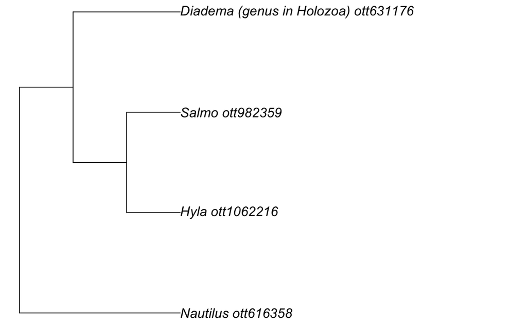

```r
plot(my_tree, no.margin=TRUE)
```

```r
my_Ptree <- tol_induced_subtree(ott_ids = P_resolved_names$ott_id)
```

```
Progress [---------------------------------] 0/138 (  0) ?s
Progress [==============================] 138/138 (100)  0s
```

```
Dropping singleton nodes with labels: Magnoliophyta ott99252, mrcaott2ott2645, mrcaott2ott35778, Mesangiospermae ott5298374, mrcaott2ott10930, mrcaott2ott969, mrcaott2ott62529, mrcaott2ott8379, Gunneridae ott853757, mrcaott2ott2464, mrcaott2ott8384, fabids ott565281, mrcaott2ott345, Malpighiales ott…
```

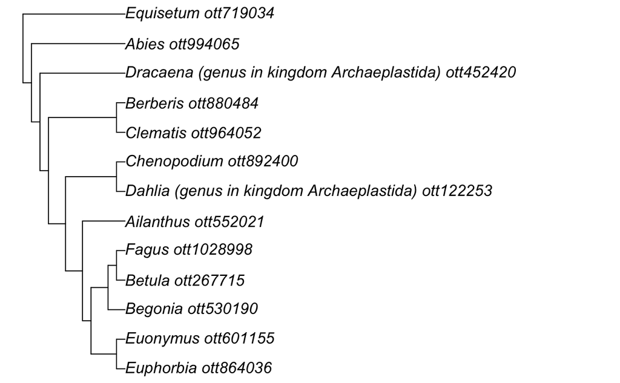

```r
plot(my_Ptree, no.margin=TRUE)
```

#### What about getting a tree for an entire taxonomic group, or from a published paper

It is possible to get trees for entire taxonomic groups as they exist inside of OTOL, but this may be a bit overwhelming for highly diverse plant groups.

```r
#For the family Illiciaceae
illicium_id <- tnrs_match_names("Illiciaceae")
illicium_tree <- tol_subtree(ott_id = ott_id(illicium_id))
```

```
Progress [-----------------------------------] 0/4 (  0) ?s
Progress [==================================] 4/4 (100)  0s
```

```
Dropping singleton nodes with labels: Illicium cubense ott69846, Illicium dunnianum ott318179, Schisandra propinqua ott1059404, Schisandra bicolor ott912632
```

[figure not shown]

```r
plot(illicium_tree, type = "fan")
```

```r
#For the just the genus Pseudostuga (douglas fir and relatives)
pseudotsuga_id <- tnrs_match_names("Pseudotsuga")
pseudotsuga_id
```

| search_string | unique_name | approximate_match | ott_id | is_synonym | flags | number_matches |
| --- | --- | --- | --- | --- | --- | --- |
| pseudotsuga | Pseudotsuga | FALSE | 1075718 | FALSE |  | 1 |

```r
pseudotsuga_tree <- tol_subtree(ott_id = ott_id(pseudotsuga_id))
```

```
Progress [-----------------------------------] 0/1 (  0) ?s
Progress [==================================] 1/1 (100)  0s
```

```
Dropping singleton nodes with labels: Pseudotsuga menziesii ott1075713
```

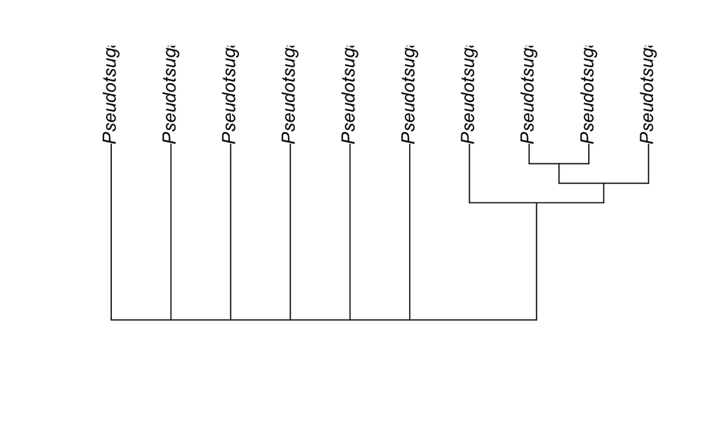

```r
plot(pseudotsuga_tree, type = "phylogram", direction = "upwards")
```

This can be a frustrating process if you are not somewhat familiar with the plant kingdom, but these examples give you a glimipse of the power of this open database.

## There is so much data in Open Tree of Life, which is linked to TreeBase

You may recall that in class on Friday we tried to get information about the genus Artocarpus, just from the command Phylomatic. It was uninformative.

In Treebase, you can locate data archived and associated with the cited paper about the phylogeny of Artocarpus.

https://tree.opentreeoflife.org/curator/study/view/pg_171

Going to the tab for “Files” then shows that this study is in Treebase.

Clicking on Treebase brings you to this page: https://treebase.org/treebase-web/search/study/summary.html?id=10011

And the scrolling to the bottom gives a way to download data in Nexus format.

[figure not shown]

```r
Artocarpus_id <- tnrs_match_names("Artocarapus")
artocarpus_tree <- tol_subtree(ott_id = ott_id(Artocarpus_id))
plot(artocarpus_tree, type = "fan")
```

If you read an interesting paper, you can go and get the tree data for the paper and re-anlyze it, or extend the analysis.

Here is an example of a published paper:

https://doi.org/10.3389/fbioe.2018.00072

Snyman et al 2018 Assessing the likelihood of gene flow from sugarcane to wild relatives in South Africa. Frontiers in Bioengineering and Biotechnology.

It’s possible to go into OTOL and/or treebase and download data from this study, which is available in nexus format.

If you open the fie S22812.nex in a text editor, or if you read the paper, you can find out information for how the tip labels (which are numbers) correspond to real named taxa.

```r
getwd()
```

```
[1] "/Users/txismis/Documents/GitHub/portfolio-3-maiteibanez"
```

```r
Ataxa <- read.nexus("S22812.nex")
```

```
numerical expression has 3 elements: only the first used
```

```r
print(Ataxa)
```

```
Phylogenetic tree with 50 tips and 49 internal nodes.

Tip labels:
    1, 2, 3, 4, 5, 6, ...

Rooted; includes branch lengths.
```

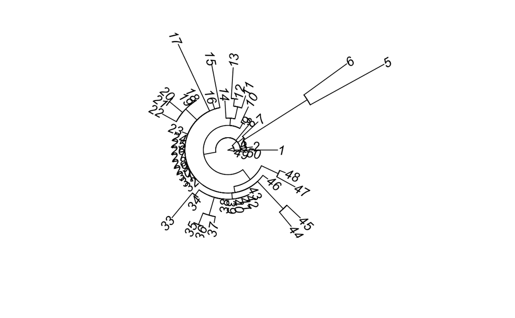

```r
plot(Ataxa, type = "fan", show.tip.label = T)
```

## SAVING DISPLAYED TREES

You can save a displayed tree to PDF (possibly better than a screen capture etc.) as shown below.

```r
pdffn = "tr2_plants.pdf"
pdf(file=pdffn)
plot(tr2_plants, type="unrooted", edge.width=5, edge.color="blue", lab4ut="axial")
dev.off()
```

In Macs (and maybe PCs), this will open the PDF from R:

```r
cmdstr = paste("open ", pdffn, sep="")
system(cmdstr)
```

## SAVING FILES: important for reproducing trees later

You can save the Newick code for any tree typed in (or imported in) as a named text file. That makes it easier to later re-import the exact tree.

Code below will store the new file in your working directory. You may want to then make a copy of it and store it elsewhere, too. (You can do that outside of R Studio, or using Files in the lower right windowframe.)

```r
newick_fn = "tr2_plants"
write.tree(tr2_plants, file=newick_fn)
```

#### MINI-EXERCISE

1 What does our list of plants from above look like on a phylogenetic tree? Remember that we assigned as P_resolved_names for the output when we resolved our list of plant genera: “Abies”, “Ailanthus”, “Begonia”, “Berberis”, “Betula”, “Chenopodium”, “Clematis”, “Dahlia”, “Dracaena”, “Equisetum”, “Euonymus”, “Euphorbia”, “Fagus”

#### More Information - the ROTL Vignette and FAQ

To look into some other issues, open the vignette for ROTL (which will appear in the viewer in the lower right of R Studio.) There is an FAQ to help with issues such as mismatches between the taxa requested and the taxa and OTT IDs returned, or for checking to ensure that the taxa being requested is correct.

```r
vignette("how-to-use-rotl", package="rotl")
```

Another option might be to use the package TREEBASE to access the data repository TREEBASE, where authors archive data from publications about phylogenetics. https://treebase.org/treebase-web/home.html

#### And Beyond!

This is just a start. Even if you’re not an evolutionary systematist wanting to infer a complete phylogeny to improve the systematics of a taxon of plants, there’s a lot more you do with this sort of data in R.

You could gather more data on your species using packages that connect to trait databases like BIEN.

In Digital Lab 4, we will delve into exploring species co-occurrence using not only VEGAN but also the package PICANTE, which can assess whether or not there is phylogenetic signal in the community composition and community assembly (co-existing species in the community). A central question in this area is whether closely related species more likely or less likely to co-exist within a community? On the one hand, related species may be phenotypically similar and more likely to co-occur. On the other hand, related species that are phenotypically similar may compete strongly, with the a superior competitior excluding inferior competitors.

Lots of food for thought!